# 1 Introduction to statistical analysis

Kachigan (1986) defines statistical analysis as the:

- Collection,
- Organization, and
- Interpretation of data according to well-defined procedures

In this course we will use Kachigan’s definition as a framework and focus on aspects of collection (experimental design), organization (using descriptive and inferential approaches), and interpretation.

One of the primary facets of quantitative analysis is the need to be creative in your approaches - the methods outlined in this class provide the foundation for analysis but the practitioner is encouraged to explore the methods and practices in their discipline to best address the needs for interpretation.

## 1.1 Data Collection

Krebs: “Not everything that can be measured should be measured.”

Prior to study we need to understand clearly and succinctly what the specific research focus is. Once this is unambiguous to the scientist, then process of data collection can begin. At this stage, it is necessary to define the variables (observations) that will be collected. Variables are anything that can be measured and exhibit variation and may vary

- among entities,
- among space,
- and in time

## 1.2 Types of Measurement

### 1.2.1 Categorical (entities are divided into distinct categories):

Binary variable: There are only two categories.

- Dead or alive.

Nominal variable: There are more than two categories.

- Whether someone is an omnivore, vegetarian, vegan, or fruitarian.

Ordinal variable: The same as a nominal variable but the categories have a logical order.

- Whether people got a fail, a pass, a merit or a distinction in their exam.

### 1.2.2 Continuous (entities get a distinct score):

Interval variable: Equal intervals on the variable represent equal differences in the property being measured.

- e.g. the difference between 6 and 8 is equivalent to the difference between 13 and 15.

## 1.3 Data Managment (from Malin Pinsky)

1. Keep lab notebooks to record what we did, learned, or produced each day. Can be physical notebooks, text files, Evernote, Jupyter notebooks, etc.
2. Establish a mechanism to facilitate collaboration and sharing within the lab.
3. Use descriptive file names
4. Keep our raw data in related to the project, unless the data files are too large.
5. Use a folder called “data” within the repository.
6. Store raw data with metadata describing what’s in the file and what the columns mean - what is metadata?
7. If we clean the data, we often use a folder called something like “data-raw” and a folder called “data-clean” to differentiate data in its original form from data that has been manipulated. Have “master” or “original” and “tidy” versions of files and name them appropriately.
8. If using data downloaded from another data source, we often have a folder called “data_dl” for downloaded data. Include the data source in a README file for reproducibility.
9. Work in the cloud (Dropbox, OneDrive)
10. We use scripts to process data, make models, do analyses, etc.

## 1.4 Data Organization (Broman and Woo, 2018)

- Spreadsheets continue to to be a primary way for data storage, analysis, and visualization
- Multipurpose (positive and negative)
- Can be error prone to make large sweeping changes - hard to retrace your steps
- Organization is critical for reproducible research and archiving

## 1.5 Consistency

1. Use consistent codes for categorical variables
2. Use a consistent fixed code for any missing values
3. Use consistent variable names
4. Use a consistent data layout in multiple files
5. Use a consistent format for all dates
6. Use consistent phrases in your notes
7. Be careful about extra spaces within cells

## 1.6 Variable naming convention

- As a general rule, do not use spaces, either in variable names or file names
- Instead, use underscores or perhaps hyphens

Also, why these:

- no empty cells - hmm, maybe
- one item per cell
- recatangular data layout
- don’t use font and cell colors as annotation
- .csv backups

# 2 Univariate Frequency Distributions

-Relative Frequency

-Cumulative frequency

- A tally of how frequently occurring a value is among a set of measured objects.
- What does a qualitative evaluation of the frequency distribution allow?
- Data reduction technique with a tradeoff

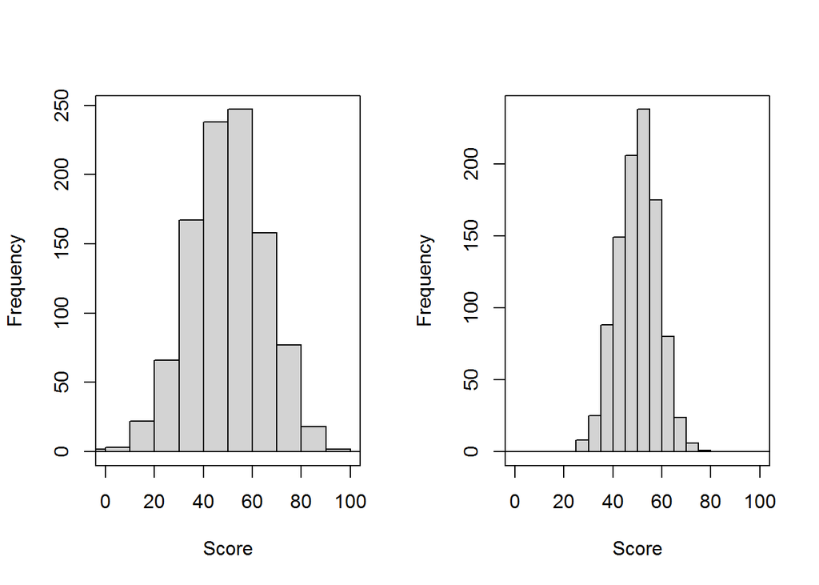

Determination of the Amount of Phosphorous in Leaves: A Frequency Table of Continuous Data

| Phosphorous concentration | Frequency |
| --- | --- |
| 8.1 to 8.2 | 2 |
| 8.2 to 8.3 | 6 |
| 8.3 to 8.4 | 8 |
| 8.4 to 8.5 | 11 |
| 8.5 to 8.6 | 17 |
| 8.6 to 8.7 | 17 |
| 8.7 to 8.8 | 24 |
| 8.8 to 8.9 | 18 |
| 8.9 to 9.0 | 13 |
| 9.0 to 9.1 | 10 |
| 9.1 to 9.2 | 4 |

Total frequency = 130 = n

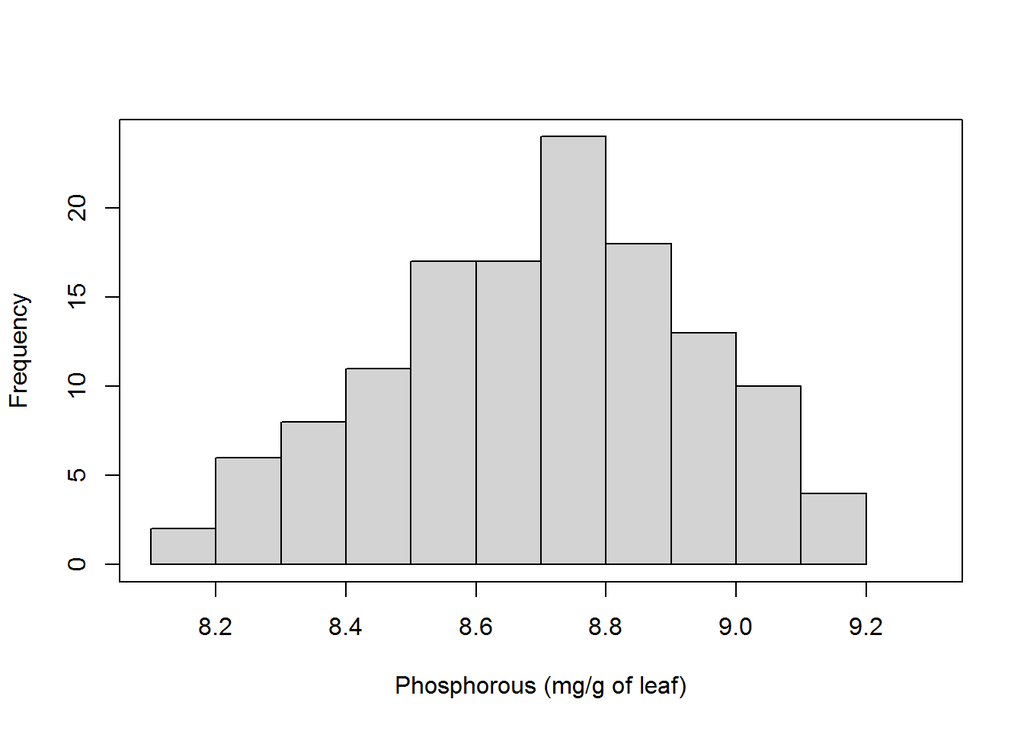

## 2.1 Cumulative Frequency Distributions

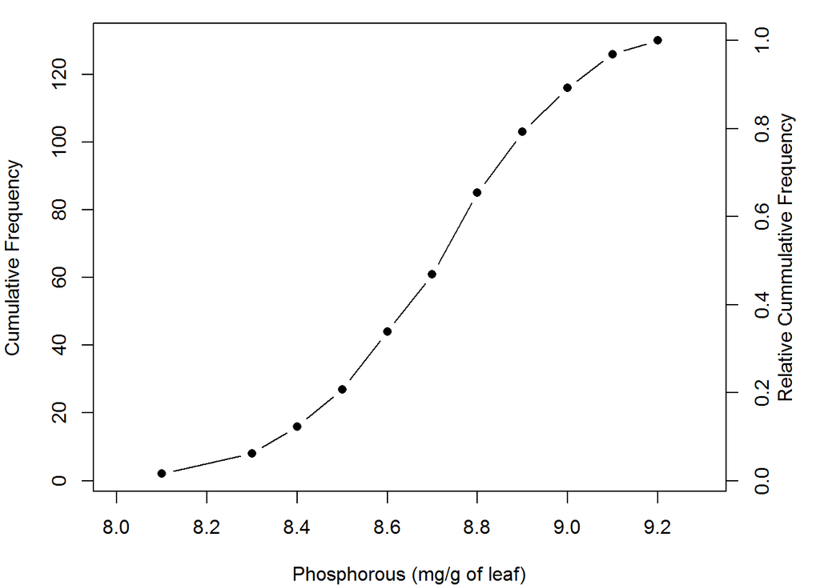

Determination of the Amount of Phosphorous in Leaves: A Frequency Table of Continuous Data

[output not shown]

Total frequency = 130 = n

### 2.1.1 What Interval to Choose?

Domain knowledge

## 2.2 Frequency Distributions

### 2.2.1 Empirical and Theoretical

Empirical: observed finite

Theoretical: infinite number of observations

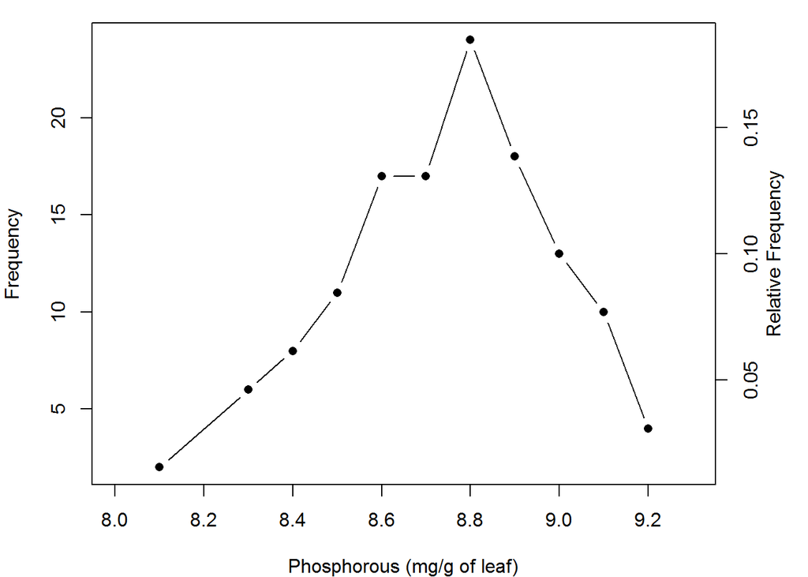

# 3 The Normal Distribution

- The equation for the normal (Gaussian) distribution:

$Y_i = \frac{1}{\sigma\sqrt2\pi}e^{-(X_i-\mu)^2/2\sigma^2}$

- Lets looks at some of the general characteristics of this model
- What are the parameters
- What are characteristics of parameters
- How do the parameters control/determine the shape

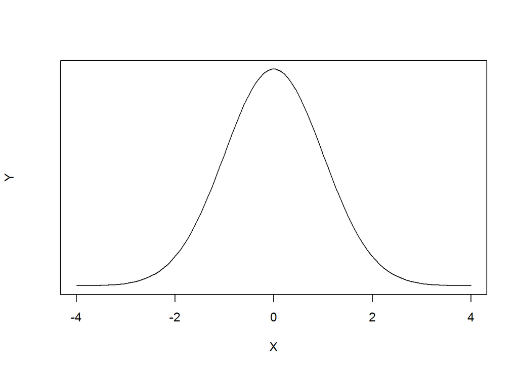

- Different Means, Identical Standard Deviation

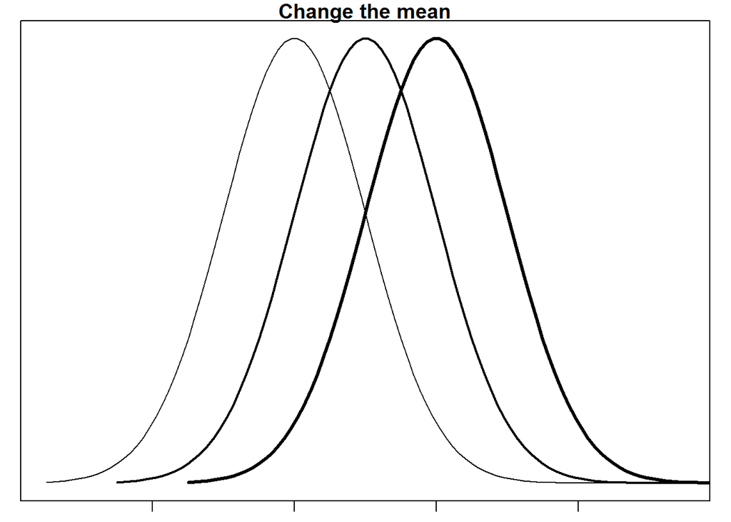

- Same Mean, Different Standard Deviation

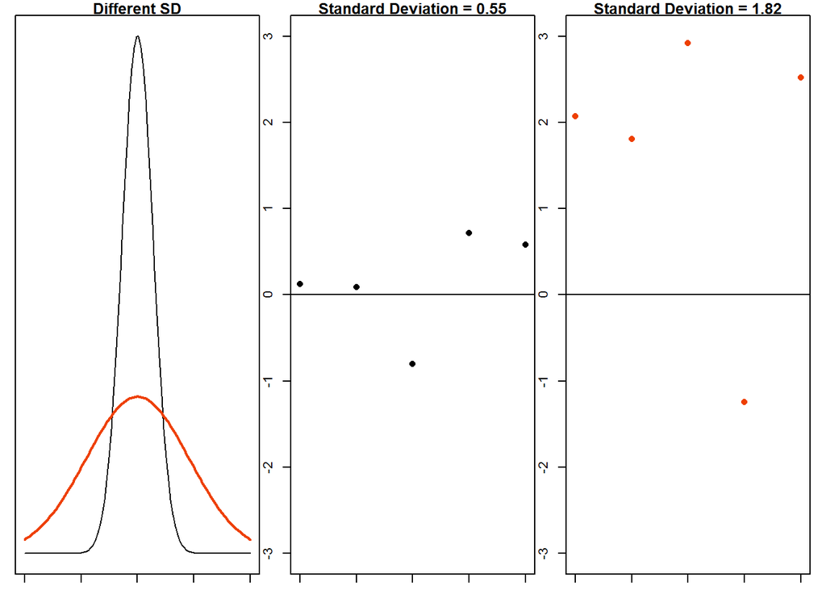

## 3.1 Sample from a Normal Distribution

Normal distribution sampling theorem:

- Sampling distribution is normal when the population distribution is normal.
- Sample mean = population mean
- Sample sd = population *s*

### 3.1.1 Central limit theorem

- The central limit theorem (CLT) states that the distribution of sample means approximates a normal distribution as the sample size becomes larger regardless of the population distribution shape.

## 3.2 Parameter Estimation

Goal:

- Achieve an unbiased estimate - Long-run (infinite sampling)
- Derive an efficient estimator - Fewest number samples to obtain accurate value

## 3.3 The normal distribution, your first statistical model

$outcome_i = (model) + error_i$

$Y_{i,obs} = \frac{1}{\sigma\sqrt2\pi}e^{-(X_i-\mu)^2/2\sigma^2} + error_{i}$

- In statistics we fit models to our data (i.e. we use a statistical model to represent what is happening in the world)
- The mean, the measure of central tendency
- The mean is the hypothetical value of the most common outcome. However, it is not a perfect representation of the characteristics of the data.
- The Standard Deviation is the measure of dispersion (precision)
- How can we assess how well the mean represents reality?

## 3.4 Quantifying Error

- A deviation is the difference between the mean (*expected*) and the *observed* data (the outcome of the sample).
- The deviation of *observed* and *expected* value is also called: the residual, error, or residual error
- Deviations can be calculated by taking each score and subtracting the mean from it:

When the normal fitting models:

$deviation = x_i - \bar{x}$

$error_i = outcome_i - (model_i)$

- In the figure below the expected value is zero, and the residual error for each of the five samples is plotted.

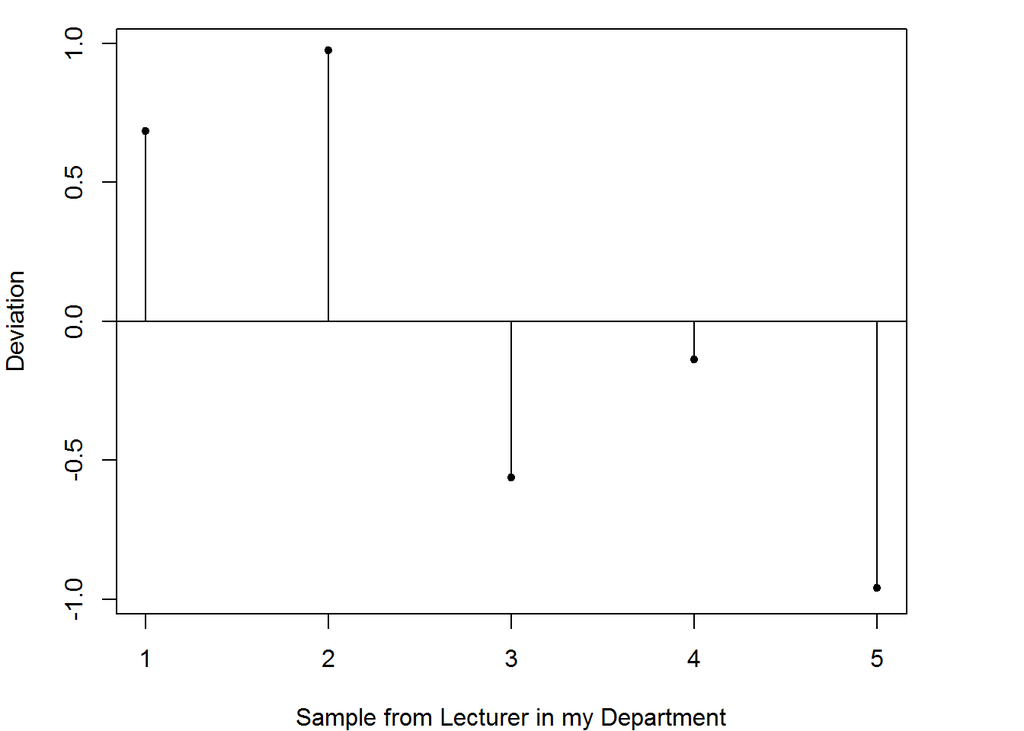

Should we use the Total Error as an estimate of uncertainty?

- We could sum $i^{th}$ error terms from 1 to n.

| Score | Mean | Deviation |
| --- | --- | --- |
| 1 | 2.6 | -1.6 |
| 2 |  | -0.6 |
| 3 |  | 0.4 |
| 3 |  | 0.4 |
| 4 |  | 1.4 |
|  | Sum = | 0 |

$\Sigma(x_i - \bar{x}) = 0$

### 3.4.1 Sum of Squared Errors

- We could add the deviations to find out the total error, but the deviations ‘cancel out’ (some are positive and others negative)
- Therefore, we square each deviation.
- If we add these squared deviations we get the sum of squared errors (SS).

| Score | Mean | Deviation | Sqaured Deviation |
| --- | --- | --- | --- |
| 1 | 2.6 | -1.6 | 2.56 |
| 2 |  | -0.6 | 0.36 |
| 3 |  | 0.4 | 0.16 |
| 3 |  | 0.4 | 0.16 |
| 4 |  | 1.4 | 1.96 |
|  |  | Total | 5.20 |

$SS = \Sigma(X - \bar{X})^2 = 5.20$

- The sum of squares is a good measure of overall variability, but is dependent on the number of scores.

### 3.4.2 Variance

- We calculate the average variability (average variability of each sample) by dividing by the number of scores minus one (n-1).
- The quantity n - 1 is termed *degrees of freedom*. It is the maximum number of logically independent values, those with the freedom to vary in the sample
- The sum of squares divided by the degrees of freedom is called the variance (s<sup>2</sup>).

Sample variance: $(s^2) = \frac{SS}{n-1} = \frac{\Sigma(x_i-\bar{x})^2}{n-1}$

Contrast this with the population variance:

Population variance: $(\sigma^2) = \frac{SS}{N} = \frac{\Sigma^n_{i=1}(x_i-\mu)^2}{N}$

### 3.4.3 Standard Deviation

- The variance has one problem: it is measured in units<sup>2</sup> (The original units, like the numbers are squared.).
- This isn’t a very meaningful metric so we take the square root value.
- This is the sample standard deviation:

$s = \sqrt\frac{\Sigma^n_{i=1}(x_i-\bar{x})^2}{n-1}$

### 3.4.4 Summary of variance estimates

The sum of squares, variance, and standard deviation represent the same thing:

- The fit of the mean to the data, how well the mean represents the observed data
- The variability in the data when modeled using the mean

## 3.5 Other meansures of variation

### 3.5.1 Range

The Range

- The smallest score subtracted from the largest

Example

- Number of friends of 11 Facebook users.
- 22, 40, 53, 57, 93, 98, 103, 108, 116, 121, 252
- Range = 252 - 22 = 230
- Very biased by outliers, why?

### 3.5.2 The Interquartile Range

- The values that split the sorted data into four equal parts.
- First or lower quartile (the range values of the first 25% of values in ordered sequence)
- Second quartile (the range values of the first 25 to 50% of values in ordered sequence)
- Third quartile (the range values of the first 50 to 75% of values in ordered sequence)
- Fourth quartile (the range values of the first 75 to 100% of values in ordered sequence)

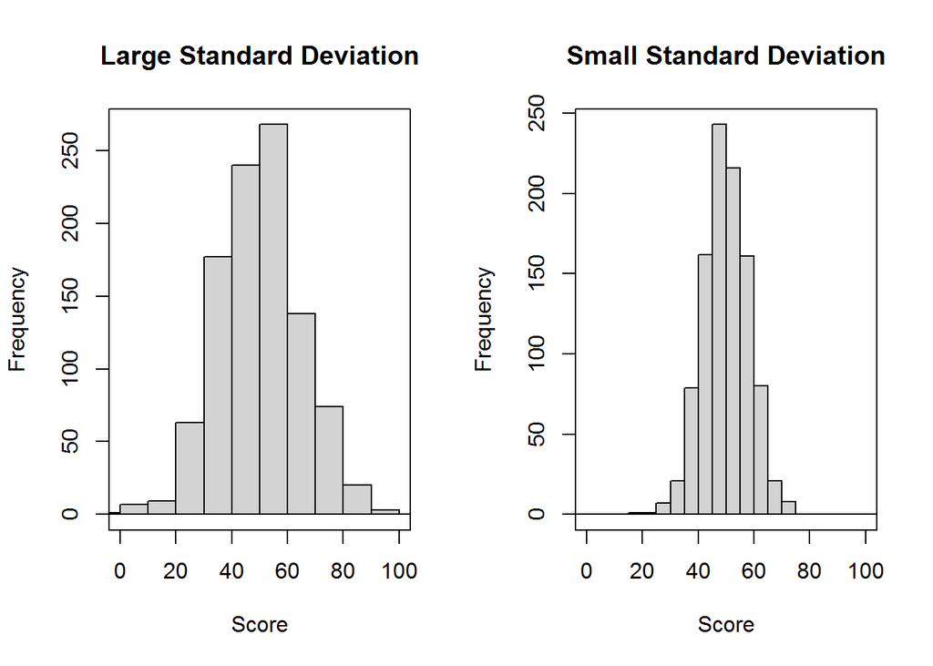

*How does the Interquartile Range vary between the two histograms?*

## 3.6 *Z*-scores

### 3.6.1 Properties of *Z*-scores - Centering and Scaling

- Standardizing a score with respect to the other scores in the group.
- Expresses a score in terms of how many standard deviations it is away from the mean.
- Converts a distribution to a z-score distribution with mean of 0 and SD = 1.

$z = \frac{X-\bar{X}}{S}$

| Obs | Centered Obs | Scaled Centered Obs, Z score | Prob (obs < Z) | Prob (Obs > Z) |
| --- | --- | --- | --- | --- |
| -1.308 | -1.344 | -1.103 | 0.135 | 0.865 |
| 1.358 | 1.323 | 1.086 | 0.861 | 0.139 |
| -1.949 | -1.985 | -1.630 | 0.052 | 0.948 |
| 1.103 | 1.068 | 0.877 | 0.810 | 0.190 |
| -0.433 | -0.468 | -0.384 | 0.350 | 0.650 |
| 1.025 | 0.990 | 0.813 | 0.792 | 0.208 |
| 0.944 | 0.909 | 0.747 | 0.772 | 0.228 |
| -1.333 | -1.368 | -1.123 | 0.131 | 0.869 |
| 0.938 | 0.903 | 0.741 | 0.771 | 0.229 |
| 0.006 | -0.029 | -0.024 | 0.491 | 0.509 |

| mean | sd |
| --- | --- |
| 0.035 | 1.218 |

### 3.6.2 Properties of *Z*-scores - Quantiles

- 1.96 definesthe top 2.5% of the distribution.
- -1.96 defines the bottom 2.5% of the distribution.
- As such, 95% of z-scores lie between -1.96 and 1.96.
- 99% of z-scores lie between -2.58 and 2.58.
- 99.9% of them lie between -3.29 and 3.29.
- Let’s look at a [Z Table](http://www.z-table.com/)

### 3.6.3 Areas Under the Normal Curve for different quantile values

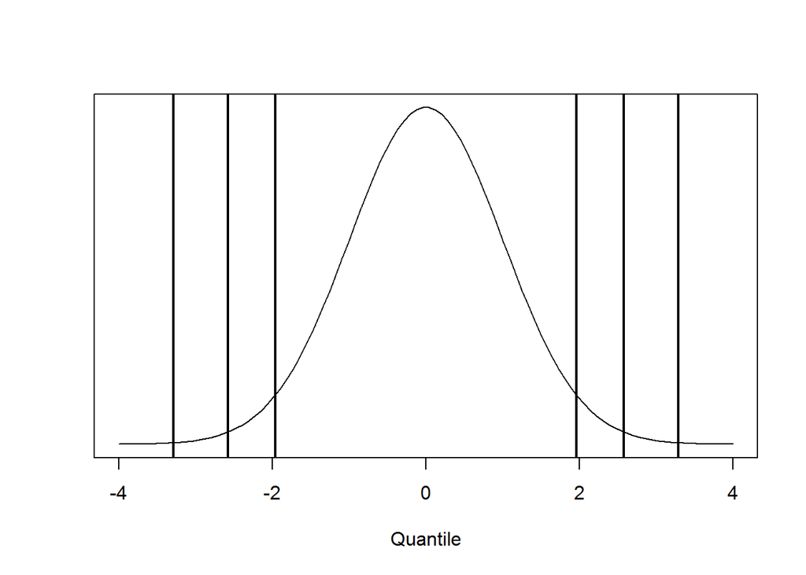

# 4 Sampling and Parameter Estimation

## 4.1 Random samples

- Every possible member of the population has an equal probability of being included in the sample.
- Ex: scientific exit polling vs. twitter polls to estimate proportion voting for a candidate.
- Think of a normally distributed frequency distribution as the population distribution:

How would the sampling distribution vary if samples were non-random?

- Only statistically valid data that can be used for analysis - the first assumption of parametric statistics.
- We will generally make an inspection of the data and/or the residuals to ensure that they are normally distributed.
- Ensuring that data are collected in a random fashion allows statistics to be calculated. Non-random data collection disallows this.
- Independence is also a critical aspect of sampling - the sampling of one element will not impact or predict the value of another element.

## 4.2 Parameter Estimates - Unbiased

- Parameters are estimated quantities that could describe any number of population characteristics (the characteristics of variables).
- We are generally focused on the mean and variance, estimated parameters could be the mean, median, mode.
- One aspect of parameter estimation is to get a *point estimate* - approximation of the true value of the population, but does not provide information about the precision of the estimate.
- The best estimate of $\mu$ is $\bar{x}$.
- The best estimate of $\sigma$ is $s$.
- We strive for an unbiased estimate of population paramters: Unbiased means that the expected value is equal to the true value (accuracy)

## 4.3 Parameter Estimates - Efficient

- The second property we want is to have parameters be efficient
- This has to do with the relationship of variance to sample size and is concerned with understanding how does sampling impact the estimate - variance should be reduced when sampling is increased.

## 4.4 Interval Estimation

- Reporting point estimates alone is unsatisfactory - we need an estimate of the variation.
- We want to know how close the sample statistic is to the population parameter.
- Interval estimation is concerned making statements saying how confident or certain we are that the populaiton parameter resides in an interval of values.
- e.g. There is a 0.95 probability that the value of $\mu$ resides between 6.2 and 9.7.

## 4.5 Confidence Interval

- Confidence intervals involve:
1. Identification of associated probability
2. Specification of the interval
- So how do we determine confidence intervals in practice:
- In the first case, let’s use or general equation for a statistical model:

$Statistic = Parameter \pm Error$ (From Kachigan, p. 138)

$Paramter = Statistic \pm Error$

$\mu = \bar{x} \pm Error$

- We will never know the magnitude of the true error? How large is the combined effect of sampling and process error. However, we can attach a probability that the error is a certain size. Now, we want to solve for the Statistic.

$\bar{x} = \mu \pm Error$

- If we take an infinite number of samples from the population, we will get an estimate of the error term, $\sigma$.
- The error in sampling, from an *infinite* number of samples, is equal to the variation in the sample means, the standard distribution (sd) equals the standard error of the mean.
- So this takes us back to our *Z*-score:
- What is the z value in which 95% of the values are under the curve?
- Let’s look at a [Z Table](http://www.z-table.com/)

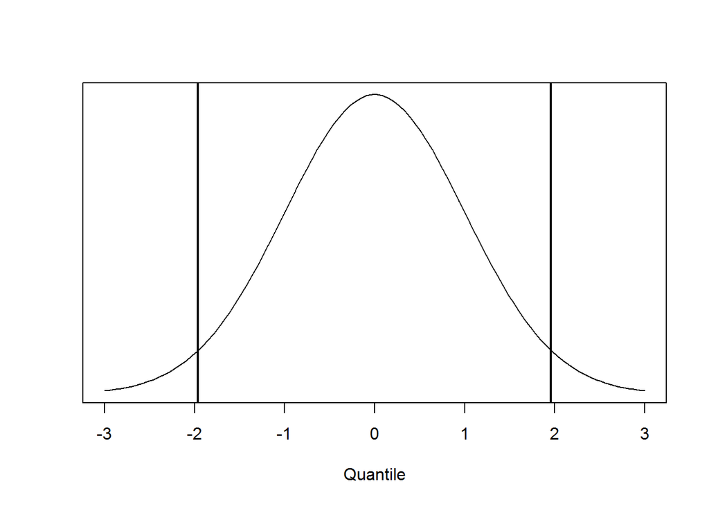

$\mu = \bar{x} \pm 1.96\sigma$ (95% Certainty)

$\mu = \bar{x} \pm ? \sigma$ (99% Certainty)

- The above presumes that we have a very good knowledge of the population parameter $\sigma$, which is generally not the case. We do not sample populations and infinite number of times.

## 4.6 Confidence Intervals of the Mean from samples

- The determination of the sampling interval from populations with unknown $\sigma$ we will use our best estimate of $\sigma$, which is *s*.
- Similarly, we will use the *t* distribution to model the variability, you will see that it is flatter and has larger tails - what does this mean to our estimate of the confidence interval?
- The *t* distribution is a one parameter distribution, *df* is the parameter and it controls the shape of the distribution. The model is platykurtic at small sample sizes.
- *df* is *n* - 1.
- To model the confidence interval we assume that the distribution of the variables are normally distributed.
- Allow us to determine the interval estimates of an estimated parameter, contingent on the values of estimates of parameters derived from sampling, in a probabilistic way.
- Let’s look at a [t Table](http://www.ttable.org/)

$\mu = \bar{x} \pm t_{df}{s_{\bar{x}}}$ (95% Certainty, with *n* = 10?)

$\mu = \bar{x} \pm t_{df}{s_{\bar{x}}}$ (99% Certainty, with *n* = 10?)

$\mu = \bar{x} \pm t_{df}{s_{\bar{x}}}$ (99% Certainty, with *n* = 50?)

# 5 Hypothesis Testing and Power

## 5.1 Statistical Hypothesis Testing

- State a testable hypothesis
- $H_0$ Null hypothesis
- $H_A$ Alternative hypothesis
- Declare $\alpha$ level
- Collect Data
- Compare the test statistic to the critical value (determined by alpha)
- State the resulting probability
- State testable hypothesis
- These are a set of mutually exclusive and exhaustive outcomes
- The test statistic will support one or the other outcomes

$H_0: \mu = 0$, $H_A:\mu \ne 0$

$H_0: \mu = 3.5 cm$, $H_A:\mu \ne 3.5 cm$

$H_0: \mu = 10.5 kg$, $H_A:\mu \ne 10.5 kg$

## 5.2 Example: Use *Z*-score to evaluate if it is likely that a given value of the distribution is the mean value

- Is the mean fuel consumption of a population of buses equal to 20 mpg?
- What is the null hypothesis?
- We need information about the population (remember we are using *Z*-score so we know the population-level parameters $\mu$ and $\sigma$).
- Mean
- Population standard deviation
- Calculate *Z*-score for mean = 20 mpg
- Determine the associated probability that the mean is 20 mpg given:
- $\sigma$ = 0.3, $\mu$ = 19.1

## 5.3 Evaluate *Z*-score

What is the probability that we would get this *Z*-score?

Hypothetical *Z*-scores

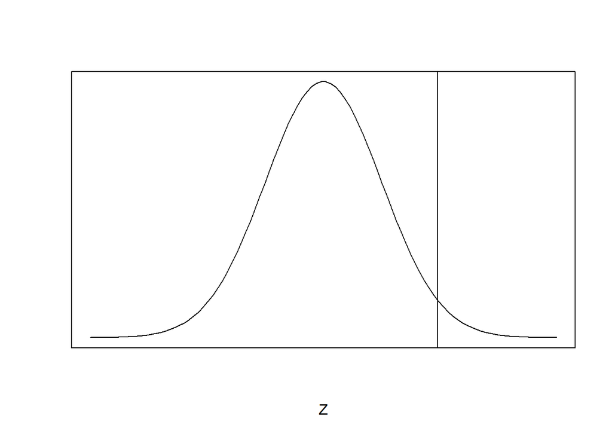

| z | .00 | .01 | .02 | .03 | .04 | .05 | .06 | .07 | .08 | .09 |
| --- | --- | --- | --- | --- | --- | --- | --- | --- | --- | --- |
| 0.0 | .5000 | .5040 | .5080 | .5120 | .5160 | .5199 | .5239 | .5279 | .5319 | .5359 |
| 0.1 | .5398 | .5438 | .5478 | .5517 | .5557 | .5596 | .5636 | .5675 | .5714 | .5753 |
| 0.2 | .5793 | .5832 | .5871 | .5910 | .5948 | .5987 | .6026 | .6064 | .6103 | .6141 |
| 0.3 | .6179 | .6217 | .6255 | .6293 | .6331 | .6368 | .6406 | .6443 | .6480 | .6517 |
| 0.4 | .6554 | .6591 | .6628 | .6664 | .6700 | .6736 | .6772 | .6808 | .6844 | .6879 |
| 0.5 | .6915 | .6950 | .6985 | .7019 | .7054 | .7088 | .7123 | .7157 | .7190 | .7224 |
| 0.6 | .7257 | .7291 | .7324 | .7357 | .7389 | .7422 | .7454 | .7486 | .7517 | .7549 |
| 0.7 | .7580 | .7611 | .7642 | .7673 | .7704 | .7734 | .7764 | .7794 | .7823 | .7852 |
| 0.8 | .7881 | .7910 | .7939 | .7967 | .7995 | .8023 | .8051 | .8078 | .8106 | .8133 |

## 5.4 Is it meaningful?

Declare $\alpha$

- Given our $\alpha$ level, how does the resulting probability compare?
- Remember, $\alpha$ is defined prior to statistical testing
- Two tail and one tail test

## 5.5 Statistical Hypothesis Testing

Evaluate if the population mean is not significantly different from some specified value.

$H_0$: $\mu$ = 0

$H_A: \mu \ne 0$

Introduce the idea of a critical value (critical quantile)

- $\alpha$ of 0.05

We have data taken from the weight change in horses given some medical treatment.

We are interested to know if the mean change in weight that we found +1.29 kg is significantly different from 0 kg.

- We calculate the *Z*-score and find that *Z* = 1.45

$P(mean \ge 1.29) = P(Z \ge 1.45) = ?$

$P(mean \le 1.29) = P(Z \le 1.45) = ?$

Z = 1.96 is the rejection region at 2.5%

- This is the ‘region of rejection’

Now we have a way to objectively reject or accept the null hypothesis.

### 5.5.1 One- and Two-Tailed Tests

Alternative to testing ‘is the value different.’

In some cases we care about the direction of the difference (is the value less than or greater than some value).

Use one-tailed test

- In general, one-tailed hypotheses about a mean are:
- $H_0:\mu\ge\mu_0$ and $H_A:\mu<\mu_0$
- In which case, H<sub>0</sub> is rejected if the test statistic is in the left-hand tail of the distribution or:
- $H_0:\mu\le\mu_0$ and $H_A:\mu>\mu_0$

Contrast the region of rejection for these.

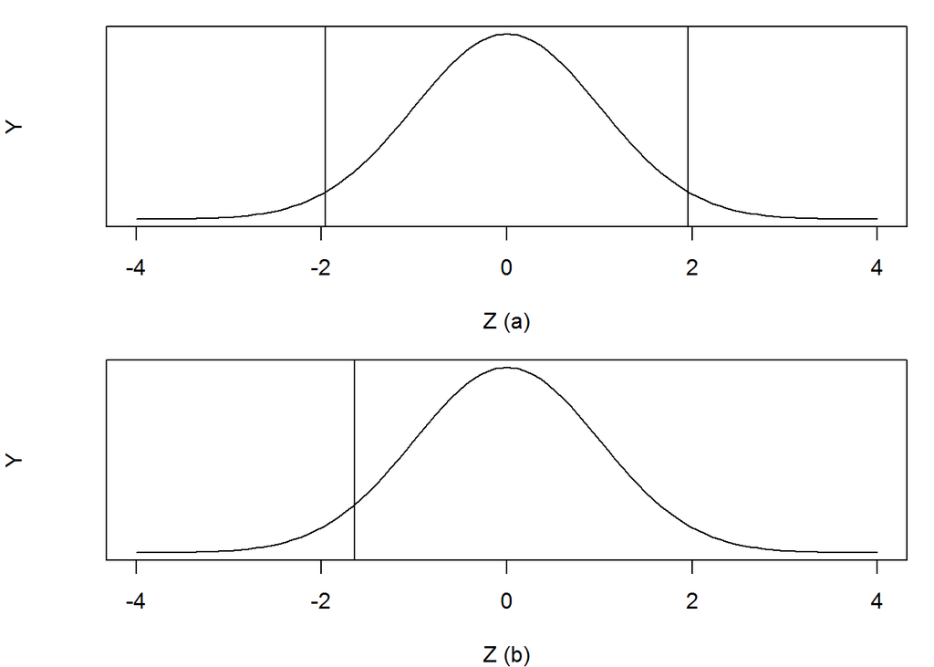

## 5.6 Type-1 and Type-2 Errors

Sometimes we:

Type 1 error or alpha error - frequency of rejecting $H_0$ when it is true.

Type 1 error rate is equal to $\alpha$.

Type 1 error: “rejecting the null hypothesis when it is true.” We rejected the null hypothesis but did so erroneously.

Type 1 error is termed ‘$\alpha$ error’ because it is equal to $\alpha$

Now we have some criteria to choose alpha.

So if your $\alpha$, or critical value is 0.10 we have a 10% probability of rejecting the null hypothesis when we should have, in fact, accepted it.

Type 2 error: “accepting the null hypothesis when it is false.”

Type 2 error or ‘$\beta$ error’ is equal to $\beta$.

|  | If H<sub>0</sub> is true | If H<sub>0</sub> is false |
| --- | --- | --- |
| If H<sub>0</sub> is rejected | Type I error | No error |
| If H<sub>0</sub> is not rejected | No error | Type II error |

*Table 4.8.1: Two Types of Errors in Hypothesis Testing*

Thought experiments:

- Ex. Endangered species conservation
- Ex. Pharmaceutical testing

|  | If H<sub>0</sub> is true | If H<sub>0</sub> is false |
| --- | --- | --- |
| If H<sub>0</sub> is rejected | $\alpha$ | $1-\beta$ (“power”) No error |
| If H<sub>0</sub> is not rejected | No error $1-\alpha$ | $\beta$ |

*Table 4.8.2: Long-term Probabilities of Outcomes in Hypothesis Testing*

### 5.6.2 Power

Power: the probability that a statistical test will reject a null hypothesis when it is false (proper rejection).

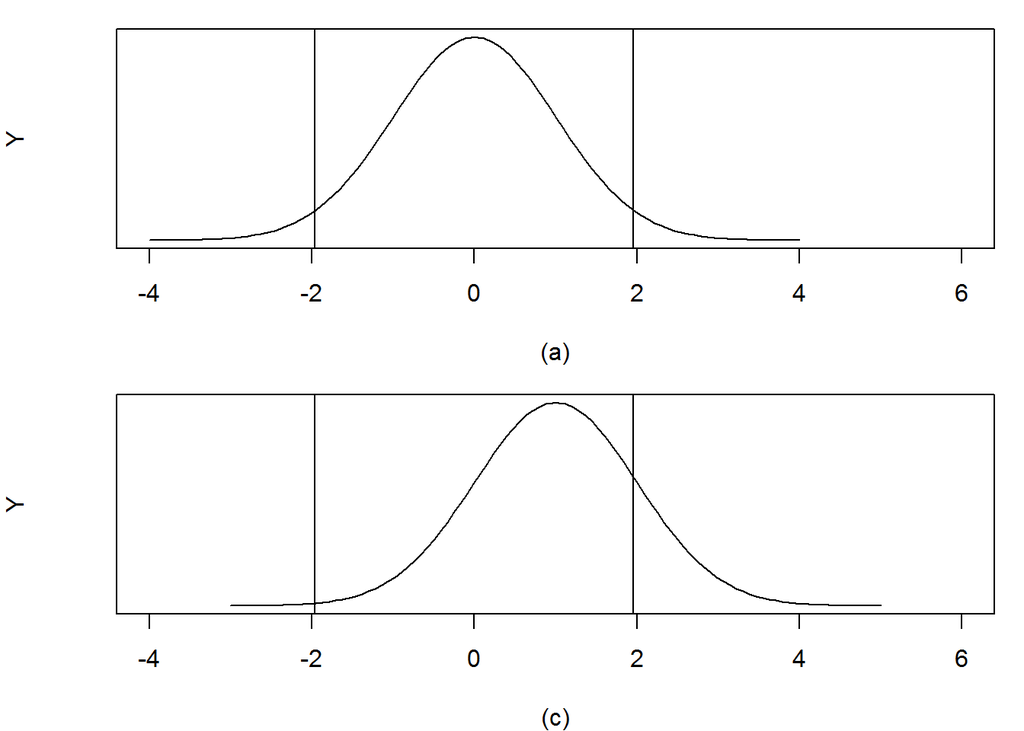

*Figure 4.9.1*

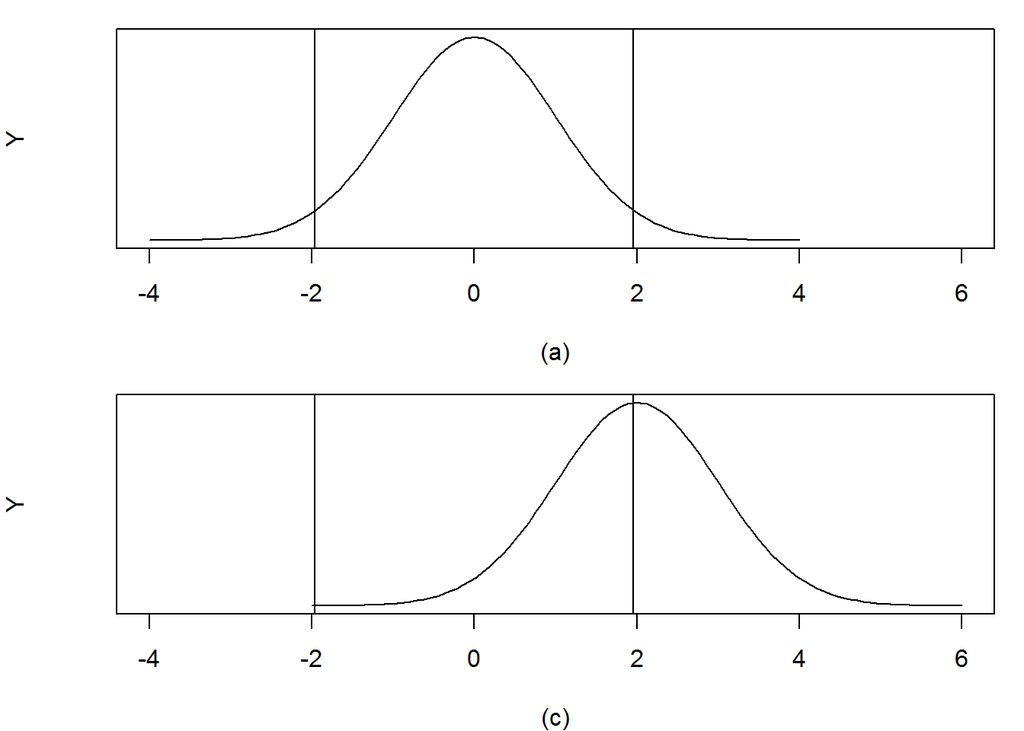

*Figure 4.9.2*

# 6 Parameteric and Non-Parameteric Correlation

## 6.1 Correlation

Correlations is a way of measuring the extent to which two variables are related.

Parametric approaches

- Pearson’s correlation coefficient

Nonparametric approaches

- Spearman’s rho
- Kendall’s tau

Interpreting correlations

Small Relationship

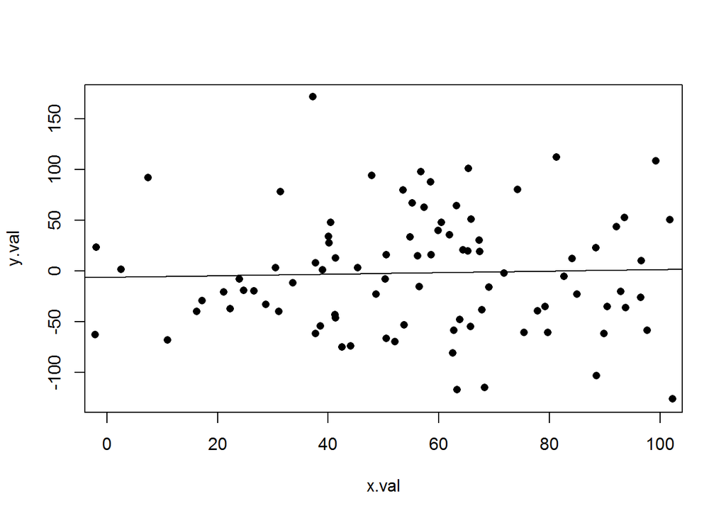

Positive Relationship

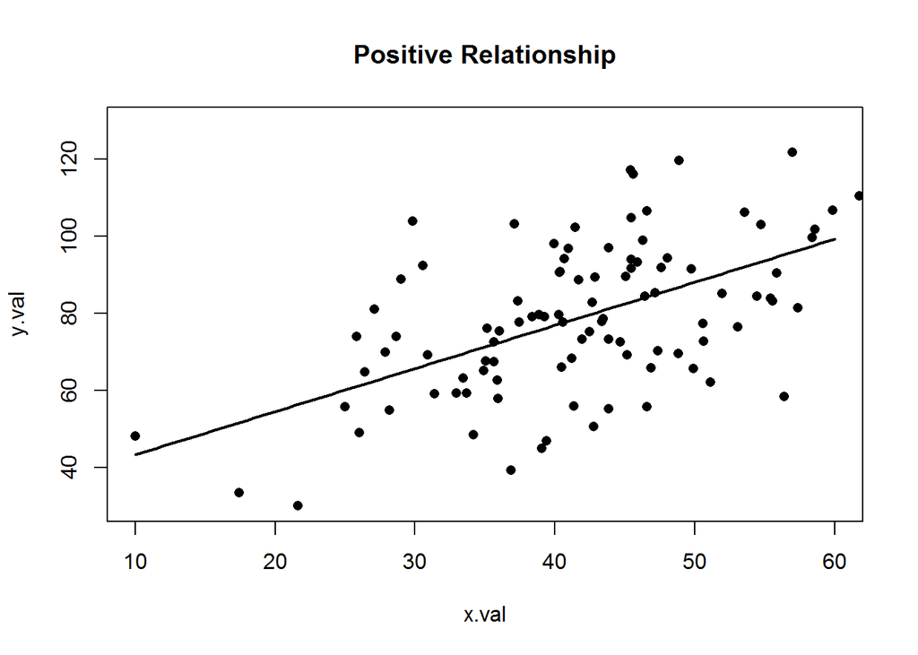

Negative Relationship

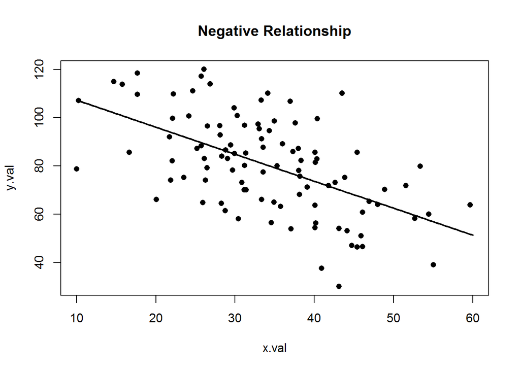

## 6.2 Quantifying the magnitude of correlation

- As one variable increases, does the other increase, decrease or stay the same?
- This can be done by calculating the covariance.
- We look at how much each score deviates from the mean.
- If both variables deviate from the mean by the same amount, they are likely to be related.

Here is the results (bivariate) of an experiment aimed at understanding the efficacy of advertising:

| Participant | 1 | 2 | 3 | 4 | 5 | Mean | SD |
| --- | --- | --- | --- | --- | --- | --- | --- |
| Adverts Watched | 5 | 4 | 4 | 6 | 8 | 5.4 | 1.67 |
| Packets Bought | 8 | 9 | 10 | 13 | 15 | 11 | 2.92 |

Residual error values:

| Participant | 1 | 2 | 3 | 4 | 5 | Mean | SD |
| --- | --- | --- | --- | --- | --- | --- | --- |
| Adverts Watched | 5 | 4 | 4 | 6 | 8 | 5.4 | 1.67 |
| Packets Bought | 8 | 9 | 10 | 13 | 15 | 11 | 2.92 |
| Advertiser Residual | -0.4 | -1.4 | -1.4 | 0.6 | 2.6 |  |  |
| Packets residual | -3 | -2 | -1 | 2 | 4 |  |  |

[figure not shown]

[figure not shown]

## 6.3 Covariance and a re-examination of variance

- Remember the variance tells us by how much scores deviate from the mean for a single variable.
- It is closely linked to the sum of squares.
- Covariance is similar - it tells is by how much scores on two variables differ from their respective means.

$variance=\frac{\Sigma(x_i - \bar{X})}{N-1}^2$

$variance=\frac{\Sigma(x_i - \bar{X})(x_i - \bar{X})}{N-1}$

- Calculate the error between the mean and each subject’s score for the first variable (*X*).
- Calculate the error between the mean and their score for the second variable (*Y*).
- Multiply these error values.
- Add these values and you get the cross product deviations.
- The covariance is the average cross-product deviations:

$cov(x,y)=\frac{\Sigma(x_i - \bar{x})(y_i - \bar{y})}{N-1}$

$cov(x,y)=\frac{(-0.4)(-3)+(-1.4)(-2)+(-1.4)(-1)+(0.6)(2)+(2.6)(4)}{4}$

$cov(x,y)=\frac{1.2+2.8+1.4+1.2+10.4}{4}$

$cov(x,y)=\frac{17}{4}$

$cov(x,y)=4.25$

## 6.4 Limitations of Covariance

The magnitude of the covariance is dependent on the units of measurement.

- e.g. the covariance of two variables measured in miles might be 4.25, but if the same scores are converted to kilometres, the covariance is 11.
- Standardize: Divide by the standard deviations of both variables.
- The standardized version of covariance is known as the correlation coefficient.
- It is unaffected by units of measurement.

## 6.5 The Correlation Coefficient

$r=\frac{cov_xy}{s_xs_y}$

$r=\frac{\Sigma(x_i - \bar{x})(y_i - \bar{y})}{(N-1)s_xs_y}$

$r=\frac{cov_xy}{s_xs_y}$

$r=\frac{4.25}{1.67 * 2.92}$

$r=0.87$

Termed Pearson-product moment correlation coefficient

It varies between -1 and +1

- 0 = no relationship

It is a testable hypothesis

Testing $H_0: \rho=0$ versus $H_A: \rho\ne0$

The standard error of the correlation coefficient is calculated as:

$S_r=\sqrt\frac{1-r^2}{n-2}$

It is a testable hypothesis

*r* = 0.870

*n* = 12 (new data set, with more samples)

We will calculate the critical value:

$t=\frac{r}{S_r}= \frac{0.870}{0.156}= 5.58$

t<sub>0.05(2),10</sub> =2.228

Testing $H_0: \rho=0$ versus $H_A: \rho\ne0$

Coefficient of determination, r^2

- By squaring the value of r you get the proportion of variance in one variable shared by the other.

## 6.6 Non-parametric Correlation

Spearman’s rho $\rho$

- Pearson’s correlation on the ranked data

Kendall’s tau ($\tau$)

- “Better” than Spearman’s for small samples

## 6.7 Spearman Rank Correlation Coefficient

*d* is the difference between two numbers in each pair of ranks

*n* = number of pairs of data

$r=1-(\frac{6\Sigma d^2}{n(n^2 - 1)})$

| Data 1 | Data 2 |
| --- | --- |
| 6 | 2 |
| 4 | 9 |
| 7 | 3 |

| Data 1 | Data 2 | Rank 1 | Rank 2 | d | d<sup>2</sup> |
| --- | --- | --- | --- | --- | --- |
| 6 | 2 | 2 | 1 |  |  |
| 4 | 9 | 1 | 3 |  |  |
| 7 | 3 | 3 | 2 |  |  |

| Data 1 | Data 2 | Rank 1 | Rank 2 | d | d<sup>2</sup> |
| --- | --- | --- | --- | --- | --- |
| 6 | 2 | 2 | 1 | 1 | 1 |
| 4 | 9 | 1 | 3 | 2 | 4 |
| 7 | 3 | 3 | 2 | 1 | 1 |

$r=1-(\frac{6\Sigma d^2}{n(n^2 - 1)})$

$=1-(\frac{6*6}{3(3^2 - 1)})$

We can use this value as the calculated *r* value